# CMSC320 Final Project, UMD, Spring ’19

Anselm Teather, Zach Kaplan, Ophir Gal

Due on May 22, 2019

# Data

We will use the famous Boston Housing data set. The entities are different suburbs of Boston, Massachusetts. We have a data set of 333 entities, which we will split into a training set and a held-out test set before we create our predictors. Each entity has 14 attributes (excluding ID). Our target variable will be `medv`.

Below is a brief description of each attribute:

1. `crim` - per capita crime rate by town.
2. `zn` - proportion of residential land zoned for lots over 25,000 sq.ft.
3. `indus` - proportion of non-retail business acres per town.
4. `chas` - Charles River dummy variable (= 1 if tract bounds river; 0 otherwise).
5. `nox` - nitrogen oxides concentration (parts per 10 million).
6. `rm` - average number of rooms per dwelling.
7. `age` - proportion of owner-occupied units built prior to 1940.
8. `dis` - weighted mean of distances to five Boston employment centres.
9. `rad` - index of accessibility to radial highways.
10. `tax` - full-value property-tax rate per $10,000.
11. `ptratio` - pupil-teacher ratio by town.
12. `black` - $1000(Bk - 0.63)^2$ where Bk is the proportion of blacks by town.
13. `lstat` - lower status of the population (percent).
14. `medv` - median value of owner-occupied homes in $1000s.

The data was downloaded from Kaggle: https://www.kaggle.com/c/boston-housing

```r
df <- read.csv("./data/train.csv", header = TRUE) %>%
  select(2:15) %>% # removing ID column
  as_data_frame()
df
```

```
## # A tibble: 333 x 14
##       crim    zn indus  chas   nox    rm   age   dis   rad   tax ptratio
##      <dbl> <dbl> <dbl> <int> <dbl> <dbl> <dbl> <dbl> <int> <int>   <dbl>
##  1 0.00632  18.0  2.31     0 0.538  6.58  65.2  4.09     1   296    15.3
##  2 0.0273    0    7.07     0 0.469  6.42  78.9  4.97     2   242    17.8
##  3 0.0324    0    2.18     0 0.458  7.00  45.8  6.06     3   222    18.7
##  4 0.0690    0    2.18     0 0.458  7.15  54.2  6.06     3   222    18.7
##  5 0.0883   12.5  7.87     0 0.524  6.01  66.6  5.56     5   311    15.2
##  6 0.225    12.5  7.87     0 0.524  6.38  94.3  6.35     5   311    15.2
##  7 0.117    12.5  7.87     0 0.524  6.01  82.9  6.23     5   311    15.2
##  8 0.0938   12.5  7.87     0 0.524  5.89  39.0  5.45     5   311    15.2
##  9 0.630     0    8.14     0 0.538  5.95  61.8  4.71     4   307    21.0
## 10 0.638     0    8.14     0 0.538  6.10  84.5  4.46     4   307    21.0
## # ... with 323 more rows, and 3 more variables: black <dbl>, lstat <dbl>,
## #   medv <dbl>
```

# Prediction Task

*Can we predict a suburb’s median housing value using different regression models?*

# Data Management

We can perform a quick check to make sure there’s no NA values.

```r
apply(df, 2, FUN=function(x) any(is.na(x)))
```

```
##    crim      zn   indus    chas     nox      rm     age     dis     rad
##   FALSE   FALSE   FALSE   FALSE   FALSE   FALSE   FALSE   FALSE   FALSE
##     tax ptratio   black   lstat    medv
##   FALSE   FALSE   FALSE   FALSE   FALSE
```

# Exploratory Data Analysis

To get an understanding of how our outcome variable, `medv`, is distributed, let’s make a histogram plot, as well as a boxplot to visualize its distribution and density.

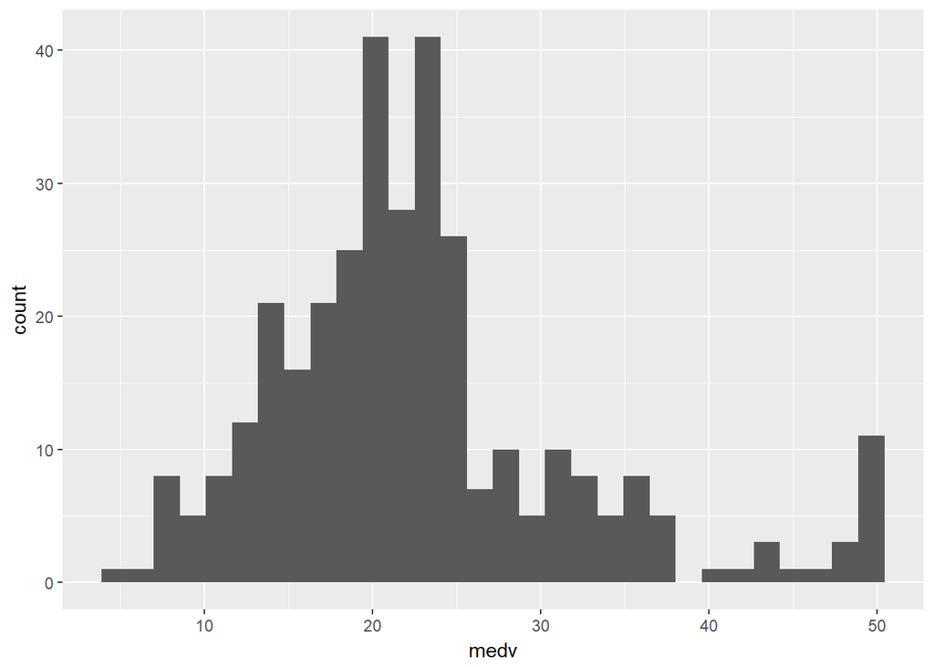

```r
ggplot(df) +
  geom_histogram(aes(x=medv))
```

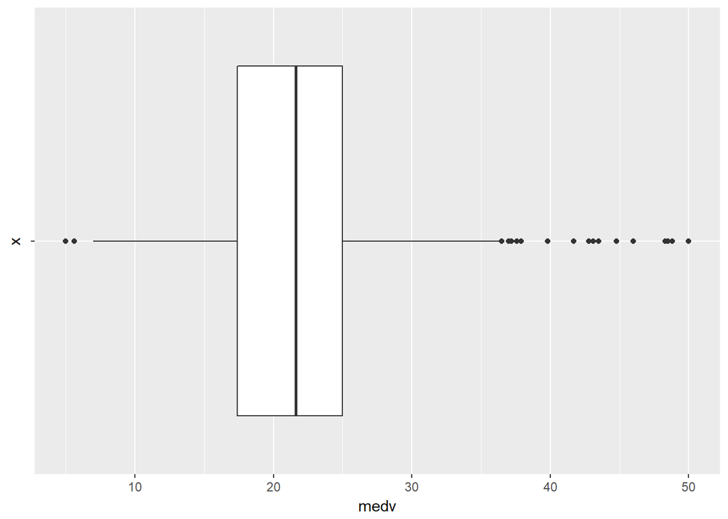

```r
ggplot(df, mapping=aes(x='',y=medv)) +
  coord_flip() +
  geom_boxplot()
```

It seems that median values for houses in different suburbs are center around 22K, with some outliers mainly above 40K. Let us plot our `medv` against all other variables, since we might want to eliminate attributes with a weak correlation to `medv` in the future.

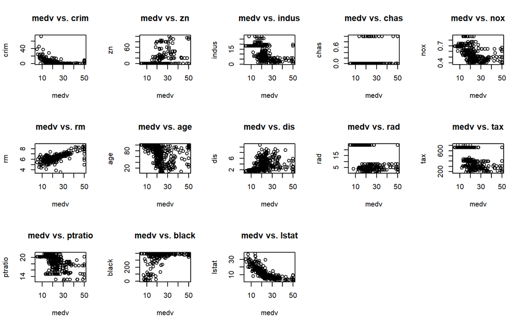

```r
attach(df)
par(mfrow=c(3,5)) # 4 figures arranged in 3 rows and 5 columns
plot(medv, crim , main="medv vs. crim")
plot(medv, zn , main="medv vs. zn")
plot(medv, indus , main="medv vs. indus")
plot(medv, chas , main="medv vs. chas")
plot(medv, nox , main="medv vs. nox")
plot(medv, rm , main="medv vs. rm")
plot(medv, age , main="medv vs. age")
plot(medv, dis , main="medv vs. dis")
plot(medv, rad , main="medv vs. rad")
plot(medv, tax , main="medv vs. tax")
plot(medv, ptratio , main="medv vs. ptratio")
plot(medv, black , main="medv vs. black")
plot(medv, lstat , main="medv vs. lstat")
```

Some variables appear more correlated to `medv` than others, with `lstat` and `rm` looking most correlated, which fits intuition since they refer to status of the population and average number of rooms per dwelling.  
Let’s use the `cor()` function to see the correlations.

```r
correlations <- tidy(cor(df)) %>%
  arrange(desc(abs(medv))) %>%
  slice(2:n()) %>%
  mutate(variables=.rownames,correlation_with_medv=medv) %>%
  select('variables', 'correlation_with_medv')

correlations
```

```
## # A tibble: 13 x 2
##    variables correlation_with_medv
##    <chr>                     <dbl>
##  1 lstat                    -0.739
##  2 rm                        0.690
##  3 ptratio                  -0.481
##  4 indus                    -0.474
##  5 tax                      -0.448
##  6 nox                      -0.413
##  7 crim                     -0.407
##  8 age                      -0.359
##  9 rad                      -0.352
## 10 zn                        0.345
## 11 black                     0.337
## 12 dis                       0.249
## 13 chas                      0.204
```

# Regression Models

Let’s split our data to a training test, and a test set. The test set will be held out while we learn our models.

```r
set.seed(123) # set seed to enable replication of results

## 75% of the training set
smp_size <- floor(0.75 * nrow(df))

## Now lets populate a testing set, and then update our training set to match
train_ind <- sample(seq_len(nrow(df)), size = smp_size)

train <- df[train_ind, ]
train
```

```
## # A tibble: 249 x 14
##       crim    zn indus  chas   nox    rm    age   dis   rad   tax ptratio
##      <dbl> <dbl> <dbl> <int> <dbl> <dbl>  <dbl> <dbl> <int> <int>   <dbl>
##  1  0.545    0   21.9      0 0.624  6.15  97.9   1.67     4   437    21.2
##  2 38.4      0   18.1      0 0.693  5.45 100     1.49    24   666    20.2
##  3  0.0866  45.0  3.44     0 0.437  7.18  26.3   6.48     5   398    15.2
##  4  9.33     0   18.1      0 0.713  6.18  98.7   2.26    24   666    20.2
##  5  4.04     0   18.1      0 0.532  6.23  90.7   3.10    24   666    20.2
##  6  0.852    0    8.14     0 0.538  5.96  89.2   4.01     4   307    21.0
##  7  0.214   22.0  5.86     0 0.431  6.44   8.90  7.40     7   330    19.1
##  8  9.92     0   18.1      0 0.740  6.25  96.6   2.20    24   666    20.2
##  9  0.762   20.0  3.97     0 0.647  5.56  62.8   1.99     5   264    13.0
## 10  0.141    0   10.6      0 0.489  6.38  32.3   3.95     4   277    18.6
## # ... with 239 more rows, and 3 more variables: black <dbl>, lstat <dbl>,
## #   medv <dbl>
```

```r
test <- df[-train_ind, ]
test
```

```
## # A tibble: 84 x 14
##      crim    zn indus  chas   nox    rm   age   dis   rad   tax ptratio
##     <dbl> <dbl> <dbl> <int> <dbl> <dbl> <dbl> <dbl> <int> <int>   <dbl>
##  1 0.0324   0    2.18     0 0.458  7.00  45.8  6.06     3   222    18.7
##  2 0.0690   0    2.18     0 0.458  7.15  54.2  6.06     3   222    18.7
##  3 0.0883  12.5  7.87     0 0.524  6.01  66.6  5.56     5   311    15.2
##  4 0.117   12.5  7.87     0 0.524  6.01  82.9  6.23     5   311    15.2
##  5 0.630    0    8.14     0 0.538  5.95  61.8  4.71     4   307    21.0
##  6 0.638    0    8.14     0 0.538  6.10  84.5  4.46     4   307    21.0
##  7 0.627    0    8.14     0 0.538  5.83  56.5  4.50     4   307    21.0
##  8 1.05     0    8.14     0 0.538  5.94  29.3  4.50     4   307    21.0
##  9 0.988    0    8.14     0 0.538  5.81 100    4.10     4   307    21.0
## 10 0.956    0    8.14     0 0.538  6.05  88.8  4.45     4   307    21.0
## # ... with 74 more rows, and 3 more variables: black <dbl>, lstat <dbl>,
## #   medv <dbl>
```

As a metric to test the accuracy of our models we will use root-mean squared error, which is given by:

$$RMSE = \sqrt{\frac{1}{n}\Sigma_{i=1}^{n}{(y_i-\hat{y}_i)^2}}$$

## Linear Regression

First, let us try generalized linear regression model with MEDV as the dependent variable and all the remaining variables as independent variables.

```r
set.seed(123) # set seed to enable replication of results

#Try linear model using all features
linRegFit <- lm(medv~., data=train)

#check cooeffs              --- SHUOLD WE JUST REMOVE THESE 2 LINES?
#data.frame(coef=round(linRegFit$coefficients,2))

# predict on test set
linRegPred <- predict(linRegFit, newdata=test)

# Root-mean squared error
linRegRMSE <- sqrt(sum((linRegPred - test$medv)^2)/length(test$medv))
linRegRMSE
```

```
## [1] 5.250004
```

As we can see the RMSE for the linear regression model using all attributes is ~5.25 .

## LASSO

Lasso regression (least absolute shrinkage and selection operator) performs variable selection that aims to increase prediction accuracy by identifying a simpler model.

```r
set.seed(123) # set seed to enable replication of results

# Find the best lambda using cross-validation
cv <- cv.glmnet(x=as.matrix(train[,1:13]), y=as.matrix(train$medv), alpha = 1, nfolds=5)

# Fit the model on the training data
lassoModel <- glmnet(x=as.matrix(train[,1:13]), y=as.matrix(train$medv), alpha = 1,
                     lambda = cv$lambda.min)

# Display regression coefficients       ## SHUOLD WE REMOVE THIS LINE?
#tidy(coef(lassoModel)) %>% select(-2)

# Make predictions on the test data
glmTest <- model.matrix(medv~., test)[,-1]
lassoPred <- predict(lassoModel, glmTest) %>% as.vector()

# Model performance metrics
lassoRMSE <- RMSE(lassoPred, test$medv)
lassoRMSE
```

```
## [1] 5.199522
```

## Random Forest

Let’s learn the random forest model using default parameters.

```r
library(randomForest)

set.seed(123) # set seed to enable replication of results

# Fit the model
rfFit <- randomForest(formula=medv~., data=train)

# Make predictions on test data
rfPred <- predict(rfFit, test)

# Model performance metrics
rfRMSE <- sqrt(sum((test$medv - (rfPred))^2)/length(test$medv))
rfRMSE
```

```
## [1] 2.818043
```

# Conclusion